# Average Utilization vs Revenue-Weighted Service Optimization

Same-scenario comparison in the expanded two-class clinic scheduling experiment

This report answers a different question from the earlier revenue-weighted report:

> **For the same clinic background and the same policy regime, what changes when the optimizer targets average utilization instead of revenue-weighted service?**

The comparison is therefore **objective-to-objective**, not simply policy-to-baseline.

The Revenue-Weighted Service Objective is

$$R_\alpha=\alpha Y_1+Y_2,$$

where $Y_1$ and $Y_2$ are completed Class 1 and Class 2 visits. We evaluate **$\alpha=1.3,1.6,$ and $2.0$**. The multiplier is a relative service-value assumption.

At $\alpha=1$, maximizing $R_\alpha$ is ranking-equivalent to maximizing total completed visits and therefore average utilization within a clinic background.

# 1 Comparison design

The expanded experiment contains 5,670 clinic backgrounds. Headline comparisons use the **3,600 heterogeneous main-range backgrounds** with $\rho\leq2.5$. Same-behavior controls are excluded from all headline summaries.

For every background and policy regime:

1. the **average-utilization optimizer** selects its best policy cell on the five search seeds;
2. the **revenue-weighted optimizer** independently selects its best policy cell for a given $\alpha$;
3. both frozen cells are evaluated on the **same ten independent evaluation seeds**;
4. this report compares their evaluated metrics **within the same background**.

The primary quantities below are therefore matched differences:

$$\text{Revenue-optimized outcome}-
\text{Average-utilization-optimized outcome}.$$

This is the cleanest way to answer how changing the objective changes the policy and its consequences.

Policy regimes remain:

| Policy | Horizon | Reservations |
| --- | --- | --- |
| Horizon only | Optimized | None |
| Reservation only | Native horizon | Quantity and window optimized |
| Both flexible | Optimized | Quantity and window optimized |

Unused protected capacity is released on the service day.

# 2 Headline result: what does revenue optimization add?

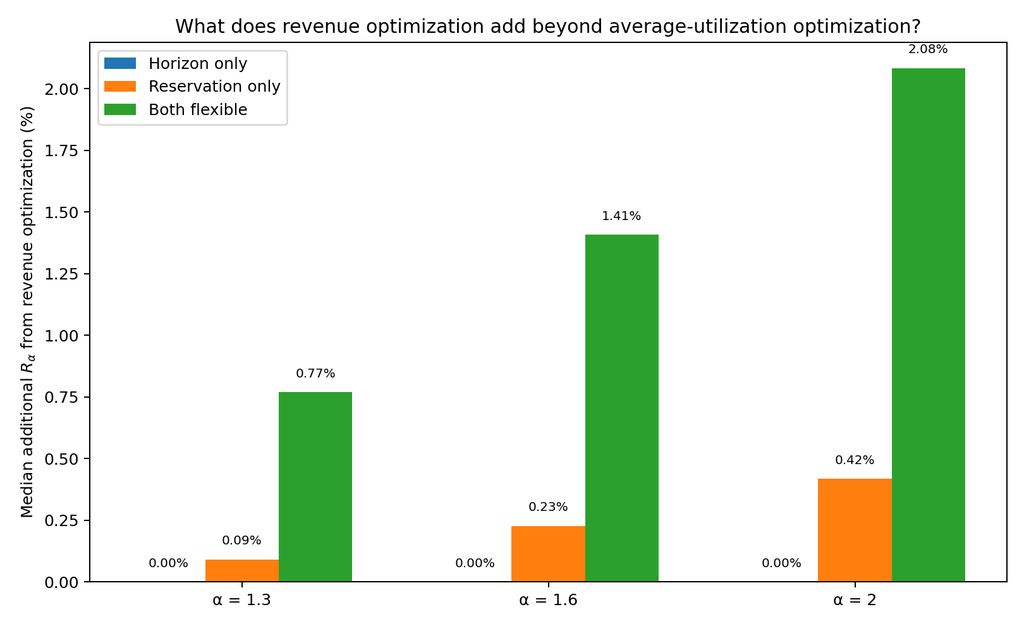

Median additional revenue-weighted service obtained by switching from average-utilization optimization to revenue-weighted optimization within the same clinic backgrounds.

| $\alpha$ | Policy | Additional $R_\alpha$ vs utilization-opt | Change in average utilization | Change in Class 1 served rate | Change in Class 2 served rate |
| --- | --- | --- | --- | --- | --- |
| 1.3 | Horizon only | 0.00% | 0.00 pp | 0.00 pp | 0.00 pp |
| 1.3 | Reservation only | +0.09% | 0.00 pp | +1.10 pp | −0.42 pp |
| 1.3 | Both flexible | **+0.77%** | **−0.01 pp** | **+4.42 pp** | **−6.73 pp** |
| 1.6 | Horizon only | 0.00% | 0.00 pp | 0.00 pp | 0.00 pp |
| 1.6 | Reservation only | +0.23% | 0.00 pp | +1.32 pp | −0.78 pp |
| 1.6 | Both flexible | **+1.41%** | **−0.02 pp** | **+4.61 pp** | **−7.07 pp** |
| 2.0 | Horizon only | 0.00% | 0.00 pp | 0.00 pp | 0.00 pp |
| 2.0 | Reservation only | +0.42% | 0.00 pp | +1.38 pp | −0.91 pp |
| 2.0 | Both flexible | **+2.08%** | **−0.03 pp** | **+4.72 pp** | **−7.60 pp** |

The core result is straightforward:

**Switching from average-utilization optimization to revenue-weighted optimization buys additional weighted service primarily by reallocating access toward Class 1, not by serving more patients overall.**

Under both-flexible optimization:

- extra $R_\alpha$ rises from **+0.77%** at $\alpha=1.3$ to **+2.08%** at $\alpha=2$;
- average utilization changes by only **−0.01 to −0.03 pp**;
- Class 1 served rate rises another **4.4–4.7 pp**;
- Class 2 served rate falls another **6.7–7.6 pp**.

These are medians of **within-background differences**, so they directly compare the two optimization objectives in the same scenarios.

## 2.1 Why horizon-only changes little

The median head-to-head difference for horizon-only is zero at all three weights. Revenue weighting can select a different horizon in some backgrounds, but in more than half the backgrounds the evaluated outcomes are the same or essentially equivalent.

The objective switch becomes consequential when the optimizer can use **reservations**, because reservations provide a direct mechanism to redirect scarce capacity toward Class 1.

# 3 Both-flexible: side-by-side outcomes relative to baseline

The next table provides context by showing what each optimizer achieves relative to the same baseline. These are separate medians across backgrounds, so the **paired differences in the preceding table are the correct measure of the objective switch**.

| $\alpha$ | Optimization objective | $R_\alpha$ vs baseline | Average utilization vs baseline | Class 1 served rate vs baseline | Class 2 served rate vs baseline |
| --- | --- | --- | --- | --- | --- |
| 1.3 | Average utilization | +2.66% | +0.36 pp | +6.49 pp | −4.54 pp |
| 1.3 | Revenue weighted | **+4.21%** | +0.36 pp | **+17.21 pp** | **−22.23 pp** |
| 1.6 | Average utilization | +3.76% | +0.36 pp | +6.49 pp | −4.54 pp |
| 1.6 | Revenue weighted | **+6.83%** | +0.36 pp | **+17.33 pp** | **−22.29 pp** |
| 2.0 | Average utilization | +5.04% | +0.36 pp | +6.49 pp | −4.54 pp |
| 2.0 | Revenue weighted | **+10.26%** | +0.35 pp | **+17.44 pp** | **−22.29 pp** |

Average-utilization optimization already creates some revenue-weighted gain because it increases completions and, in some backgrounds, changes the class mix. Revenue optimization goes substantially further by explicitly rewarding Class 1 completions.

The key contrast is that **average utilization remains essentially unchanged between the two objectives**, while class-specific access changes markedly.

# 4 Access is the main margin of adjustment

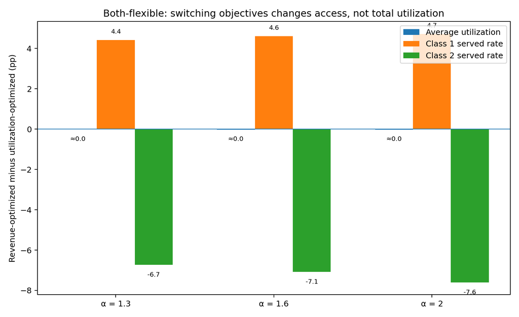

Median metric change when the both-flexible optimizer switches from average utilization to revenue-weighted service.

The near-zero utilization bars are the central feature of the comparison. The revenue optimizer is not finding a large new source of unused capacity. Instead, it is changing which class occupies the available capacity.

At $\alpha=1.6$, for example, switching objectives within the same background has median effects of:

- $R_{1.6}$: **+1.41%** relative to the utilization-optimized policy;
- average utilization: **−0.02 pp**;
- Class 1 served rate: **+4.61 pp**;
- Class 2 served rate: **−7.07 pp**.

The weighted objective therefore behaves primarily as a **prioritization objective**, whereas average-utilization optimization behaves primarily as an **efficiency objective**.

# 5 Scenario-by-scenario access tradeoff

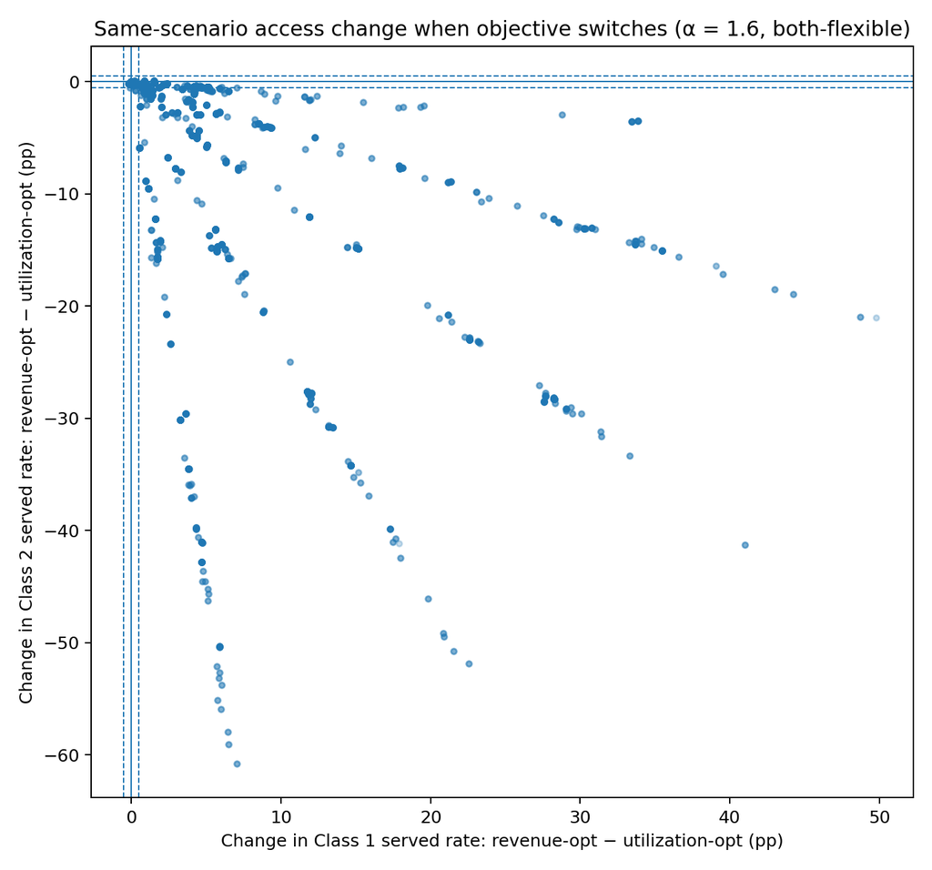

Each dot is one heterogeneous main-range clinic background. The coordinates compare the revenue-optimized both-flexible cell directly with the average-utilization-optimized both-flexible cell at alpha 1.6.

At $\alpha=1.6$:

- **96.9%** of backgrounds have a higher Class 1 served rate under revenue optimization;
- **96.7%** have a lower Class 2 served rate;
- **61.3%** have slightly lower average utilization, but the typical utilization change is only **−0.02 pp**;
- **95.0%** have a higher evaluated $R_{1.6}$.

The scatter makes the mechanism visible: most scenarios move toward **higher Class 1 access and lower Class 2 access** when the objective changes.

# 6 The selected policy itself changes

For the both-flexible regime:

| $\alpha$ | Same exact $H,Q,W$ cell | Median $H$: utilization-opt → revenue-opt | Median $Q$/capacity: utilization-opt → revenue-opt | Median $W$: utilization-opt → revenue-opt |
| --- | --- | --- | --- | --- |
| 1.3 | 9.0% | 4 → 4 days | 72% → **100%** | 4 → 4 days |
| 1.6 | 2.1% | 4 → **6 days** | 72% → **100%** | 4 → **6 days** |
| 2.0 | 1.3% | 4 → **6 days** | 72% → **100%** | 4 → **6 days** |

Thus, the two objectives almost never choose the same both-flexible policy cell once Class 1 carries meaningful extra value.

The clearest policy change is the protected quantity:

> Average-utilization optimization uses a median reservation quantity around **72% of daily capacity**, whereas unconstrained revenue optimization moves to **100% of daily capacity**.

Same-day release prevents unused protected capacity from being permanently stranded, but the larger reservation still substantially changes who receives appointments before release.

As $\alpha$ rises, the revenue optimizer also uses somewhat longer horizons and reservation windows. These settings give the optimizer more scope to preserve Class 1 access while maintaining a large protected quantity.

# 7 Class 1 population share changes the tradeoff

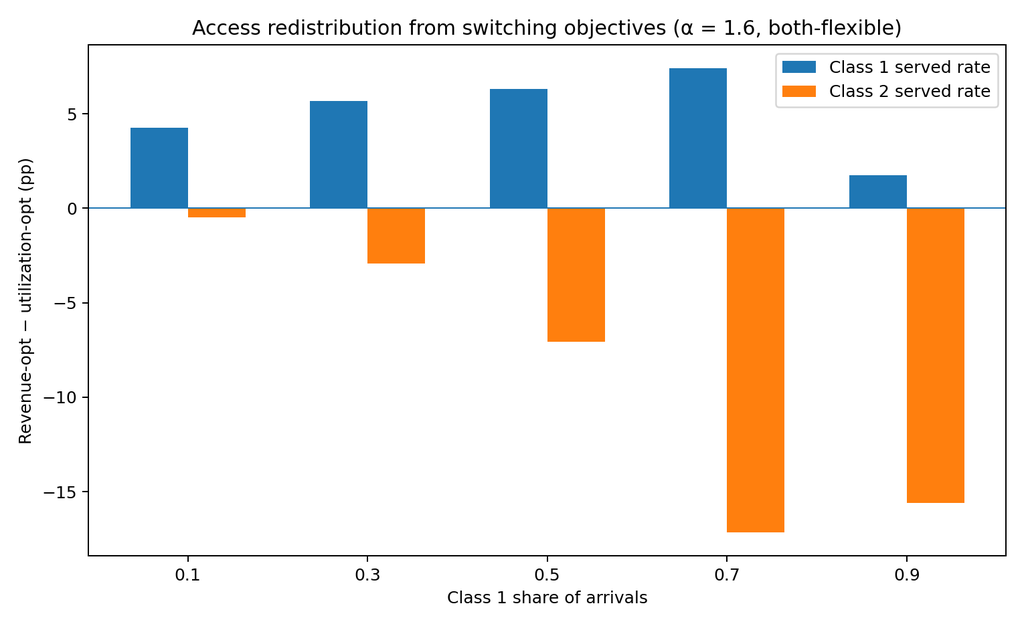

Median access change from switching objectives at alpha 1.6, by Class 1 share.

At $\alpha=1.6$ under both-flexible optimization:

| Class 1 share | Additional $R_{1.6}$ | Change in utilization | Change in Class 1 served rate | Change in Class 2 served rate |
| --- | --- | --- | --- | --- |
| 0.1 | +0.35% | −0.03 pp | +4.26 pp | **−0.49 pp** |
| 0.3 | +1.29% | −0.06 pp | +5.69 pp | −2.91 pp |
| 0.5 | +1.83% | 0.00 pp | +6.31 pp | −7.07 pp |
| 0.7 | **+4.80%** | −0.03 pp | +7.41 pp | **−17.17 pp** |
| 0.9 | +1.20% | −0.01 pp | +1.75 pp | **−15.60 pp** |

This gives the objective comparison a useful operational interpretation:

- When Class 1 is only **10%** of arrivals, revenue optimization can increase Class 1 access by about **4.3 pp** while the median additional Class 2 loss stays around **0.5 pp**.
- At intermediate-to-high Class 1 shares, substantially more capacity must be redirected to generate additional weighted value.
- The largest incremental revenue gain occurs around **70% Class 1 share**, but it comes with a very large additional Class 2 access loss.

The economics of the objective therefore depend strongly on how large the priority population is.

# 8 How to interpret the objective choice

The comparison is not “revenue optimization is better” or “utilization optimization is better.” The two objectives answer different operational questions.

**Average-utilization optimization** asks:

> Which policy produces the most completed visits from available capacity?

Its main lever is shorter booking horizons in congested, delay-sensitive clinics.

**Revenue-weighted optimization** asks:

> Which policy produces the most weighted service when a Class 1 completion is worth more?

Once reservations are available, the optimizer can increase that objective without materially increasing total completions by replacing some Class 2 service with Class 1 service.

The clinic therefore faces a real objective tradeoff:

- higher weighted service;
- almost unchanged total utilization;
- higher Class 1 access;
- lower Class 2 access.

# 9 Clinic-facing conclusions

- **The relevant comparison is objective-to-objective within the same scenarios.** Relative to the average-utilization-optimal both-flexible policy, revenue optimization adds a median **0.77%, 1.41%, and 2.08%** in $R_\alpha$ for $\alpha=1.3,1.6,2.0$.
- **The additional weighted value does not come from higher utilization.** Median utilization changes by only **−0.01 to −0.03 pp** when the objective switches.
- **The main change is access redistribution.** Revenue optimization raises Class 1 served rate by another **4.4–4.7 pp** and lowers Class 2 served rate by another **6.7–7.6 pp** under both-flexible policies.
- **Reservation flexibility is what makes the objective switch consequential.** Horizon-only differences are typically zero; reservation-only differences are modest; both-flexible differences are much larger.
- **Revenue optimization selects much more aggressive protection.** Median $Q$/capacity rises from about **72% to 100%**.
- **The access cost depends strongly on Class 1 share.** When Class 1 is rare, additional Class 2 harm can remain small; at larger Class 1 shares, the redistribution becomes substantial.
- **Average-utilization optimization is the cleaner objective when total throughput is the priority.** Revenue weighting is appropriate only if the clinic intentionally values a Class 1 completion more and accepts the corresponding distributional consequences.

Primary data input:

- `full_run_summaries/h1_patient_characteristics_expanded/release/selected_policy_outcomes.csv`

Supporting summary tables in this report are matched background-level comparisons of the frozen cells selected by the two objectives. Same-behavior controls are excluded from all headline results.